# ps5-rmarkdown

Mira Nair

2023-02-19

There are 25 columns and 13055 rows. Example of the dataset:

```
## # A tibble: 3 × 25
##   iso3  name  iso2  region sub-r…¹ inter…²  time total…³ ferti…⁴ lifeE…⁵ child…⁶
##   <chr> <chr> <chr> <chr>  <chr>   <chr>   <dbl>   <dbl>   <dbl>   <dbl>   <dbl>
## 1 ABW   Aruba AW    Ameri… Latin … Caribb…  1960   54211    4.82    65.7      NA
## 2 ABW   Aruba AW    Ameri… Latin … Caribb…  1961   55438    4.66    66.1      NA
## 3 ABW   Aruba AW    Ameri… Latin … Caribb…  1962   56225    4.47    66.4      NA
## # … with 14 more variables: youthFemaleLiteracy <dbl>, youthMaleLiteracy <dbl>,
## #   adultLiteracy <dbl>, GDP_PC <dbl>, accessElectricity <dbl>,
## #   agriculturalLand <dbl>, agricultureTractors <dbl>, cerealProduction <dbl>,
## #   fertilizerHa <dbl>, co2 <dbl>, greenhouseGases <dbl>, co2_PC <dbl>,
## #   pm2.5_35 <dbl>, battleDeaths <dbl>, and abbreviated variable names
## #   ¹`sub-region`, ²`intermediate-region`, ³totalPopulation, ⁴fertilityRate,
## #   ⁵lifeExpectancy, ⁶childMortality
```

The sample dataset looks good!

1. There are 250 countries under “name”, there are 249 countries under “iso2”, and there are 253 under “iso3”.

```
## # A tibble: 249 × 2
##    iso2      n
##    <chr> <int>
##  1 AD        1
##  2 AE        1
##  3 AF        1
##  4 AG        1
##  5 AI        1
##  6 AL        1
##  7 AM        1
##  8 AO        1
##  9 AQ        1
## 10 AR        1
## # … with 239 more rows
```

```
## # A tibble: 2 × 1
##   name
##   <chr>
## 1 <NA>
## 2 Namibia
```

```
## # A tibble: 253 × 2
##    iso3      n
##    <chr> <int>
##  1 ABW       1
##  2 AFG       1
##  3 AGO       1
##  4 AIA       1
##  5 ALA       1
##  6 ALB       1
##  7 AND       1
##  8 ARE       1
##  9 ARG       1
## 10 ARM       1
## # … with 243 more rows
```

```
## # A tibble: 1 × 1
##   name
##   <chr>
## 1 <NA>
```

3. These are the earliest and latest dates in the dataset.

```
## [1] 1960
```

```
## [1] 2019
```

```
## # A tibble: 61 × 3
## # Groups:   time [61]
##     time `is.na(co2_PC)`     n
##    <dbl> <lgl>           <int>
##  1  1960 TRUE               60
##  2  1961 TRUE               60
##  3  1962 TRUE               58
##  4  1963 TRUE               57
##  5  1964 TRUE               51
##  6  1965 TRUE               51
##  7  1966 TRUE               51
##  8  1967 TRUE               51
##  9  1968 TRUE               51
## 10  1969 TRUE               51
## # … with 51 more rows
```

2. This is a plot of CO2 emissions in the U.S, China, India, Canada, and Mexico over time.

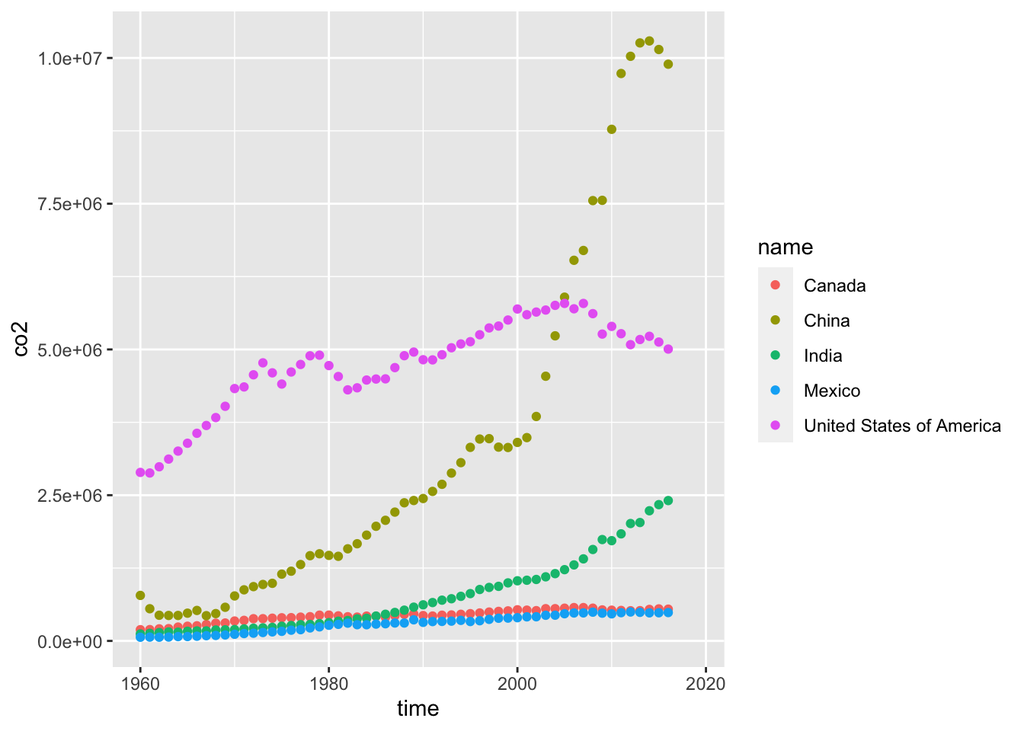

3. This is a plot of CO2 emissions per capita in the U.S, China, India, Canada, and Mexico over time.

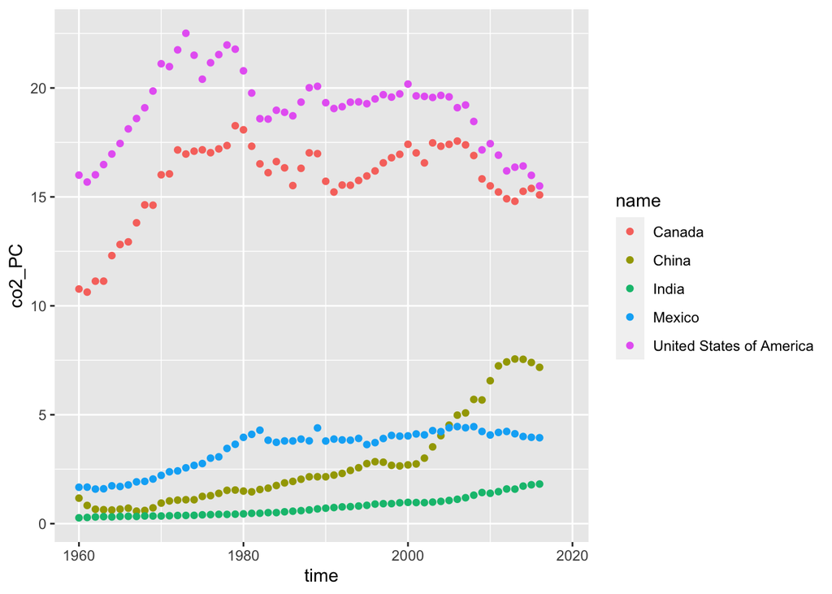

4. This table shows the average CO2 emissions per capita across the continents.

```
## # A tibble: 5 × 2
##   region       n
##   <chr>    <dbl>
## 1 Africa   0.930
## 2 Americas 6.46
## 3 Asia     6.21
## 4 Europe   7.95
## 5 Oceania  4.39
```

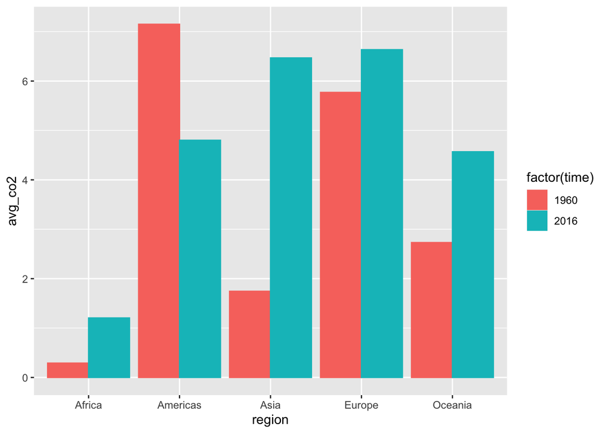

6. This table shows the three largest and three smallest CO2 emitters for each continent.

```
## # A tibble: 15 × 3
## # Groups:   region [5]
##    region        co2 name
##    <chr>       <dbl> <chr>
##  1 Asia     8776040. China
##  2 Americas 5395532. United States of America
##  3 Asia     1719691. India
##  4 Europe   1670531. Russian Federation
##  5 Asia     1172611. Japan
##  6 Europe    757881. Germany
##  7 Americas  527263. Canada
##  8 Europe    492676. United Kingdom of Great Britain and Northern Ireland
##  9 Africa    469816. South Africa
## 10 Americas  464308. Mexico
## 11 Oceania   390862. Australia
## 12 Africa    202715. Egypt
## 13 Africa    119178. Algeria
## 14 Oceania    31753. New Zealand
## 15 Oceania     4763. Papua New Guinea
```

```
## # A tibble: 15 × 3
## # Groups:   region [5]
##    region      co2 name
##    <chr>     <dbl> <chr>
##  1 Africa    99.0  Sao Tome and Principe
##  2 Africa   161.   Comoros
##  3 Africa   238.   Guinea-Bissau
##  4 Americas 172.   Dominica
##  5 Americas 183.   Turks and Caicos Islands
##  6 Americas 198.   Virgin Islands (British)
##  7 Asia     235.   Timor-Leste
##  8 Asia     488.   Bhutan
##  9 Asia     935.   Maldives
## 10 Europe    58.7  Liechtenstein
## 11 Europe   466.   Gibraltar
## 12 Europe   517.   Andorra
## 13 Oceania    7.33 Tuvalu
## 14 Oceania   44.0  Nauru
## 15 Oceania   58.7  Kiribati
```

—>4. GDP per Capita

1. GDP per capita versus life expectancy in 1960

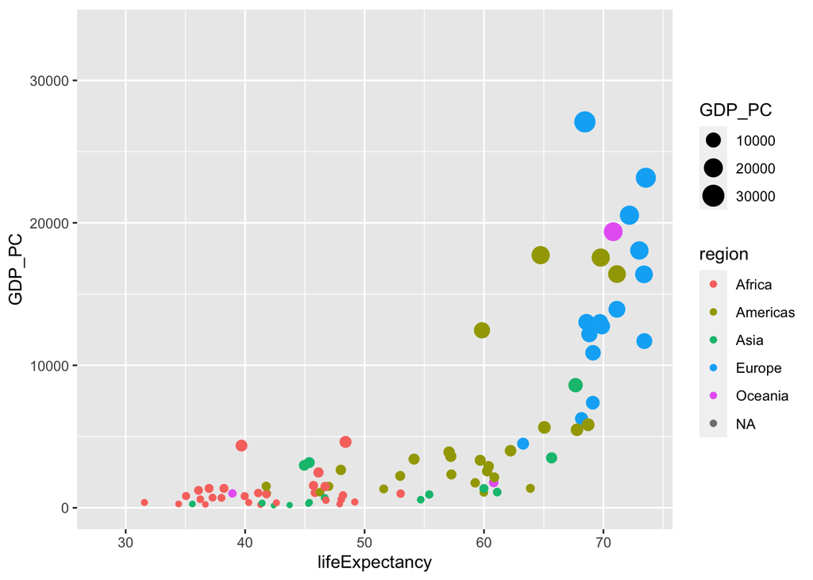

2. GDP per capita versus life expectancy in 2019

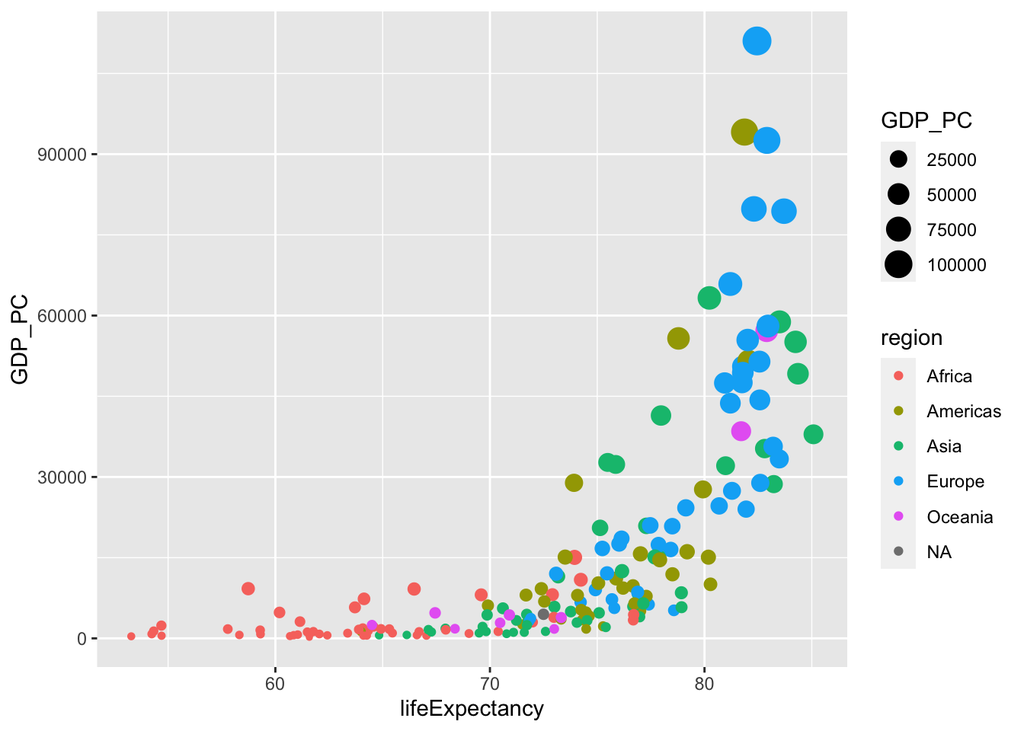

3. The plots overall show the same pattern of Western countries having a higher life expectancy but the change between the years shows that every country is still increasing its life expectancy.
4. Yes the results fit.

```
## # A tibble: 10 × 3
## # Groups:   region [5]
##    region    time avg_le
##    <chr>    <dbl>  <dbl>
##  1 Africa    1960   41.5
##  2 Africa    2019   64.1
##  3 Americas  1960   58.6
##  4 Americas  2019   75.8
##  5 Asia      1960   51.6
##  6 Asia      2019   74.6
##  7 Europe    1960   68.3
##  8 Europe    2019   79.4
##  9 Oceania   1960   56.4
## 10 Oceania   2019   73.5
```

```
## # A tibble: 433 × 4
## # Groups:   region [6]
##    region    time lifeExpectancy lediff
##    <chr>    <dbl>          <dbl>  <dbl>
##  1 Americas  1960           65.7 NA
##  2 Americas  2019           76.3  0.141
##  3 Asia      1960           32.4 NA
##  4 Asia      2019           64.8  0.347
##  5 Africa    1960           37.5 NA
##  6 Africa    2019           61.1  0.365
##  7 Europe    1960           62.3 NA
##  8 Europe    2019           78.6  0.115
##  9 Europe    1960           NA   NA
## 10 Europe    2019           NA   NA
## # … with 423 more rows
```

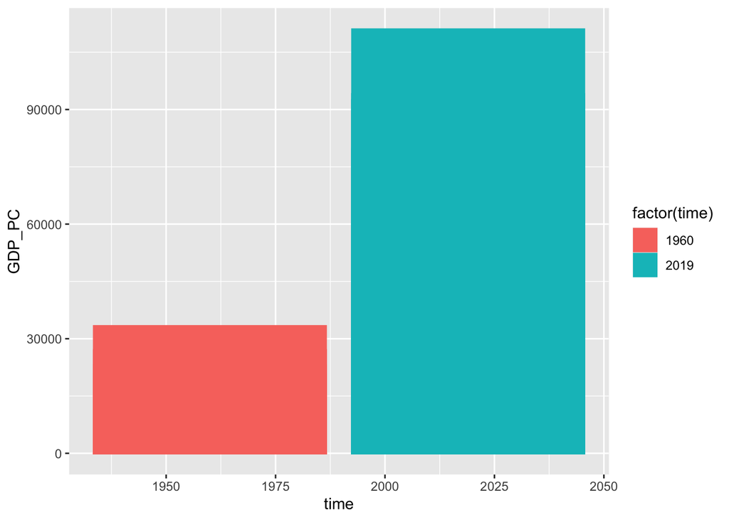

```r
plot <- gapminder%>%
  group_by(GDP_PC, time)%>%
  filter(!is.na(GDP_PC),
         time %in% c(1960, 2019)) %>%
  summarize(avg_GDP = mean(GDP_PC, na.re = TRUE))
ggplot(plot, aes( time, GDP_PC, col = factor(time), fill = factor(time), na.re=TRUE)) +
  geom_bar(stat = "identity", position = "dodge", na.re=TRUE)
```

The United States is ranked 19 in life expectancy in 1960.

The United States is ranked 48 in life expectancy in 2019.